# INFO 550 Homework 1 Solutions

Scott Gillespie

March 23, 2016

## PART I:

Solutions for SQLite questions #1 - 7 (copied from SQLite database)

The proceeding chunk performs the following tasks:

1.) Creates a character string containing SQL code for each question.  
2.) Pastes the character string for each question into a single list named ‘sqlList’ using a for loop.  
3.) Utilizes a function (“sqlFunction”) to calculate the results of an input SQL query using the ‘dbFetch’ and ‘dbSendQuery’ functions from the DBI package.  
4.) Outputs the results of each query into a list.

```r
sqlQuestion1<-("SELECT COUNT(*) FROM violations
               WHERE description LIKE ('%vermin%');")


sqlQuestion2<-("SELECT COUNT(*) FROM violations
                WHERE ((risk_category = 'High Risk') AND description NOT LIKE ('%vermin%'));")


sqlQuestion3<-("SELECT COUNT(*) FROM inspections
                WHERE ((date BETWEEN 20140401 AND 20140501) AND (type LIKE ('%routine%')));")


sqlQuestion4<-("SELECT business_id, score, date, type FROM inspections
                WHERE score != 'NA'
                ORDER BY score ASC
                LIMIT 10;")


sqlQuestion5<-("SELECT DISTINCT postal_code FROM businesses
                WHERE LENGTH(postal_code) = 5 AND postal_code != '00000';")


sqlQuestion6<-("SELECT name, postal_code, COUNT(name) AS mex_count FROM businesses
                WHERE name LIKE ('%mex%')
                GROUP BY postal_code
                ORDER BY mex_count DESC;")


sqlQuestion7<-("SELECT businesses.business_id, name, score FROM businesses, inspections
                WHERE ((businesses.business_id = inspections.business_id) AND (name LIKE ('%mex%')) AND (score != 'NA'))
                ORDER BY score ASC
                LIMIT 10;")

sqlList<-list()
for (i in 1:7){
  sqlList[i] <- list(get(paste0('sqlQuestion',i)))
}

sqlFunction<-function(x){
  dbFetch(dbSendQuery(hwDB, x))
}

output<-list()
for (i in 1:7){
  output[[i]] <- sqlFunction(sqlList[[i]])
}
output
```

```
## [[1]]
##   COUNT(*)
## 1     4151
##
## [[2]]
##   COUNT(*)
## 1     6424
##
## [[3]]
##   COUNT(*)
## 1      660
##
## [[4]]
##    business_id score     date                  type
## 1         7643    42 20120125 Routine - Unscheduled
```

[output cut: 86 more lines]

Creating dplyr object tables from the SQLite database

```r
library(dplyr)
hwDBdplyr   <- src_sqlite(path="restaurants.db")
businesses  <- tbl(hwDBdplyr, "businesses")
inspections <- tbl(hwDBdplyr, "inspections")
violations  <- tbl(hwDBdplyr, "violations")
```

Running each query as before, except now utilizing dplyr package functionalities

```r
dplyrQuestion8 <- violations %>%
                  filter(description %like% ("%vermin%")) %>%
                  summarise(Count=n())
dplyrQuestion8
```

```
## Source: sqlite 3.8.6 [restaurants.db]
## From: <derived table> [?? x 1]
##
##    Count
##    (int)
## 1   4151
## ..   ...
```

```r
dplyrQuestion9 <- violations %>%
                  filter(description %not like% ("%vermin%"), (risk_category == "High Risk")) %>%
                  summarise(Count=n())
dplyrQuestion9
```

```
## Source: sqlite 3.8.6 [restaurants.db]
## From: <derived table> [?? x 1]
##
##    Count
##    (int)
## 1   6424
## ..   ...
```

```r
dplyrQuestion10 <- inspections %>%
                   filter(between(date, '20140401', '20140501'), (type %like% ('%routine%'))) %>%
                   summarise(Count=n())
dplyrQuestion10
```

```
## Source: sqlite 3.8.6 [restaurants.db]
## From: <derived table> [?? x 1]
##
##    Count
##    (int)
## 1    660
## ..   ...
```

```r
dplyrQuestion11 <- head(inspections %>%
                        select(business_id, score, date, type) %>%
                        filter(score != 'NA') %>%
                        arrange((score)),10)
dplyrQuestion11
```

```
##    business_id score     date                  type
## 1         7643    42 20120125 Routine - Unscheduled
## 2        74522    42 20131003 Routine - Unscheduled
## 3         6695    44 20120813 Routine - Unscheduled
## 4        10413    45 20120622 Routine - Unscheduled
## 5         3151    47 20111116 Routine - Unscheduled
## 6         3309    47 20120319 Routine - Unscheduled
## 7         6695    48 20130325 Routine - Unscheduled
## 8          286    49 20130725 Routine - Unscheduled
## 9          853    49 20130710 Routine - Unscheduled
## 10        3817    50 20110601 Routine - Unscheduled
```

```r
dplyrQuestion12 <- head(distinct(businesses %>%
                        select(postal_code) %>%
                        filter(length(postal_code) == 5, (postal_code != '00000'))),50)
dplyrQuestion12
```

```
##    postal_code
## 1        94104
## 2        94124
## 3        94109
## 4        94103
## 5        94133
## 6        94118
## 7        94110
## 8        94122
## 9        94115
## 10       94131
## 11       94111
## 12       94117
## 13       94107
## 14       94108
```

[output cut: 27 more lines]

```r
dplyrQuestion13 <- head(businesses %>%
                        select(name, postal_code) %>%
                        filter(name %like% ('%MEX%')) %>%
                        group_by(postal_code) %>%
                        summarise(mex_count=count(name)) %>%
                        arrange(desc(mex_count)), 50)
dplyrQuestion13
```

```
##    postal_code mex_count
## 1        94110         7
## 2        94103         4
## 3        94105         4
## 4        94114         4
## 5        94102         2
## 6        94107         2
## 7        94111         2
## 8        94112         2
## 9        94133         2
## 10       94104         1
## 11       94108         1
## 12       94117         1
## 13       94118         1
## 14       94121         1
## 15       94127         1
## 16       94132         1
## 17       94134         1
```

```r
dplyrQuestion14 <- head(inner_join(businesses, inspections,"business_id") %>%
                              select(business_id, name, score) %>%
                              filter(name %like% ('%MEX%'), (score != 'NA')) %>% arrange(score),10)
dplyrQuestion14
```

```
##    business_id                                  name score
## 1         1005          CHAVITA'S MEXICAN RESTAURANT    69
## 2         3229             TOMMYS MEXICAN RESTAURANT    70
## 3         5140                  EL FARO MEXICAN FOOD    72
## 4         1702 EL TOREADOR FONDA MEXICANA RESTAURANT    73
## 5        74593               LA PLACITA MEXICATESSEN    73
## 6         1702 EL TOREADOR FONDA MEXICANA RESTAURANT    74
## 7        70019       EL METATE CON SABOR AMEXICO LLC    74
## 8         7770              DOMINGUEZ MEXICAN BAKERY    75
## 9        74593               LA PLACITA MEXICATESSEN    76
## 10        1005          CHAVITA'S MEXICAN RESTAURANT    77
```

## PART II:

A function to quickly pull and select variables from JSON-formatted data, utilizing a web-based API provided by the NY Times. The data was copied from the NY Times website and stored locally as a file called “hw1.JSON”. This file is provided on github and the direct weblink is commented-out within the function.

```r
library(XML)
library(dplyr)
library(jsonlite)

nytimes_movies <- function(){

  jsonAPI <- fromJSON("C:/Users/sgille3/Projects/Course Work/INFO - Software Engineering/Homework/hw1.json")
  #http://api.nytimes.com/svc/movies/v2/reviews/all.json?api-key=4ce21e5e6b299a7e95d2a14a12345f5e:12:74694642
  retdf <- jsonAPI$results %>%
            select(display_title, mpaa_rating, critics_pick, thousand_best, headline, opening_date) %>%
            rename(names=display_title)

  return(retdf)
}
nyt <- nytimes_movies()
names(nyt)
```

```
## [1] "names"         "mpaa_rating"   "critics_pick"  "thousand_best"
## [5] "headline"      "opening_date"
```

```r
nyt %>%
  select(names, critics_pick, headline)
```

```
##                         names critics_pick
## 1                   Big Night            1
## 2               The Big Chill            1
## 3             The Big Red One            0
## 4              Little Big Man            1
## 5  Big Deal on Madonna Street            1
## 6                The Big Heat            1
## 7                 The Big Sky            1
## 8               The Big Clock            1
## 9      Miracle on 34th Street            1
## 10              The Big Sleep            1
##                                             headline
## 1
## 2
## 3  There's No Glory in War, Unless You Mean Survival
## 4
## 5
## 6
## 7
## 8
## 9
## 10
```

## PART III:

### Plot 1:

Average flight delays in minutes for US carriers. Arrival delays are summarized in red, and departure delays are summarized in blue. The research hypothesis concerned if more regional airlines (e.g. Hawaiian Airlines, Alaska Airlines, and Virgin America) performed better than major carriers (e.g. Frontier Airlines, Southwest Airlines, and United Airlines). Evidence from the plot seems to indicate a possible association between flight carrier type (regional vs. national) and average flight delays.

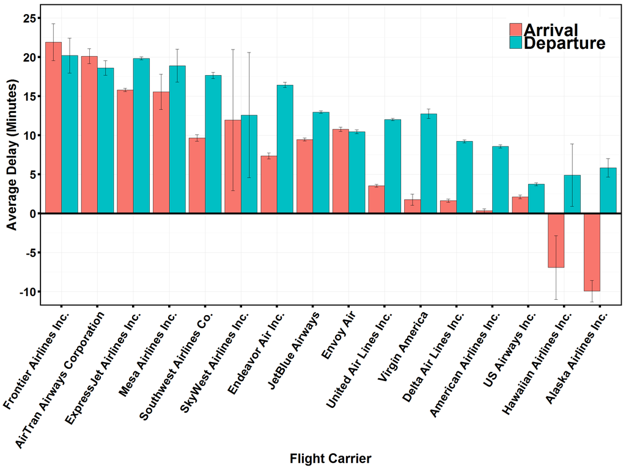

### Plot 2:

Pearson correlations between arrival delay, flight speed, and number of seats and engines. Lighter blue indicates stronger associations; whereas, darker blue indicates weaker association between the variables. From the plot, number of seats seems to correlate highly with speed of the jet; likewise, number of engines has moderate correlation with seats and speed. Interestingly, arrival delay fails to associate strongly with any of these characteristics.

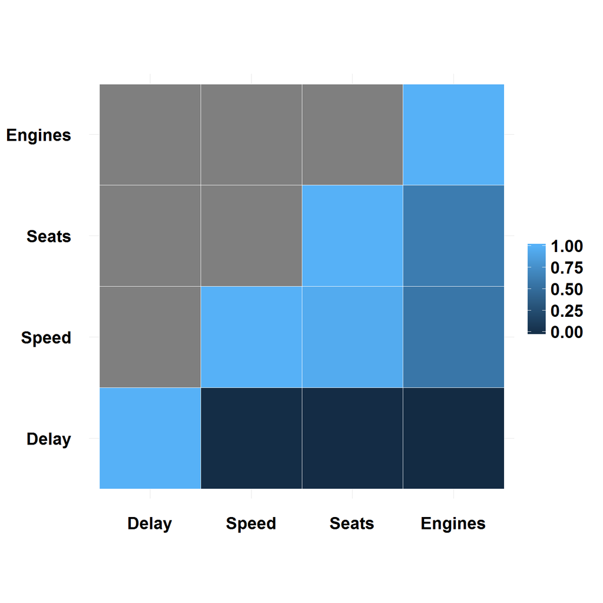